# voto_obrigatorio

```r
#load pacotes
library(readxl)
base <- read_excel("idea_export_40_616830a0840fa.xls")
library(tidyverse)
library(huxtable)
library(coefplot)
library(olsrr)
library(sjPlot)
```

Caso queira replicar, solicite-me o arquivo ‘idea_export_40_616830a0840fa.xls’ pelo meu e-mail

```r
base$Tornout <- as.numeric(base$Tornout) # arrumar problemas na codificação dos dados, transformar em numérico
```

Aqui constarão especialmente os códigos, uma análise mais opinativa sobre o voto obrigatório constará no youtube: https://www.youtube.com/channel/UC0rKmGqFWnsWozw5rftWyag/videos

# Lista completa de casos utilizados

```r
dim(base) # numero de linhas
```

```
## [1] 118   6
```

118 países

Selecionados casos de países com eleições minimamente regulares.

Foram selecionadas as eleições parlamentares mais recentes encontradas até 14 de Outubro de 2021 - https://www.idea.int/data-tools/data/voter-turnout

Lista completa dos casos - classificados pelo maior comparecimento - consta abaixo.

```r
tibble(base%>%
         arrange(desc(Tornout))%>%select(Country, Tornout, Compulsory))
```

| Country | Tornout | Compulsory |
| --- | --- | --- |
| Nauru | 95.1 | Yes |
| Malta | 92.1 | No |
| Australia | 91.9 | Yes |
| Antigua and Barbuda | 90.3 | No |
| Uruguay | 90.1 | Yes |
| Luxembourg | 89.7 | Yes |
| Faroe Islands | 89.4 | No |
| Bolivia | 88.4 | Yes |
| Belgium | 88.4 | Yes |
| Burundi | 87.3 | No |
| Sweden | 87.2 | No |
| Turkey | 86.2 | Yes |
| Aruba | 84.7 | No |
| Denmark | 84.6 | No |
| Botswana | 83.5 | No |
| New Zealand | 82.2 | No |
| Belize | 81.9 | No |
| Papua New Guinea | 81.3 | No |
| Ecuador | 81 | Yes |
| Timor-Leste | 81 | No |
| Argentina | 80.9 | Yes |
| Sao Tome and Principe | 80.7 | No |
| Iceland | 80.1 | No |
| Brazil | 79.8 | Yes |
| Cook Islands | 79.1 | No |
| Netherlands | 78.7 | No |
| Liechtenstein | 78 | Yes |
| Ghana | 77.8 | No |
| Kenya | 77.4 | No |
| Norway | 77.2 | No |

[output cut: 88 more lines]

# Objetivo:

verificar se comparecimento eleitoral é explicado por Região do globo e lei eleitoral que obriga participação

Modelo contemplado nessa análise

$Comparecimento = X1 + X2 + e$

Intercepto - usual em análises - para saber mais sobre procure no google

X1 = Obrigatoriedade do voto (efeito institucional) X2 = Região do mundo (efeito cultural)

Sendo o e = erro (o que não foi explicado pela análise, o que ficou de fora, por exemplo - desde quando tem eleições)

# Análise descritiva

```r
summary(base$Tornout)#dispersão Tornout
```

```
##    Min. 1st Qu.  Median    Mean 3rd Qu.    Max.
##   23.03   52.17   64.33   64.17   77.02   95.13
```

```r
table(base$Region)
```

```
##
##           Africa         Americas             Asia Europa Ocidental
##               23               31               11               24
##    Leste Europeu          Oceania
##               20                9
```

```r
table(base$Compulsory)
```

```
##
##  No Yes
##  95  23
```

```r
summary(base$Year)
```

```
##    Min. 1st Qu.  Median    Mean 3rd Qu.    Max.
##    2014    2018    2019    2019    2020    2021
```

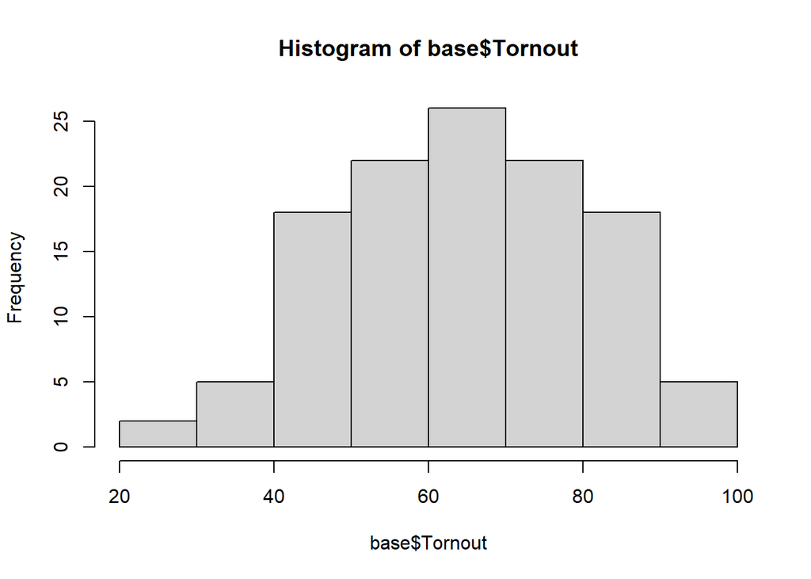

```r
hist(base$Tornout)
```

# Análise bivariada

```r
by(base$Tornout, base$Region, mean)
```

```
## base$Region: Africa
## [1] 56.63478
## ------------------------------------------------------------
## base$Region: Americas
## [1] 63.06903
## ------------------------------------------------------------
## base$Region: Asia
## [1] 67.87636
## ------------------------------------------------------------
## base$Region: Europa Ocidental
## [1] 72.2675
## ------------------------------------------------------------
## base$Region: Leste Europeu
## [1] 56.7585
## ------------------------------------------------------------
## base$Region: Oceania
## [1] 77.55889
```

```r
by(base$Tornout, base$Compulsory, mean)
```

```
## base$Compulsory: No
## [1] 62.07253
## ------------------------------------------------------------
## base$Compulsory: Yes
## [1] 72.83087
```

```r
prop.table(table(base$Region, base$Compulsory),1)
```

```
##
##                            No        Yes
##   Africa           0.95652174 0.04347826
##   Americas         0.67741935 0.32258065
##   Asia             0.81818182 0.18181818
##   Europa Ocidental 0.83333333 0.16666667
##   Leste Europeu    0.85000000 0.15000000
##   Oceania          0.66666667 0.33333333
```

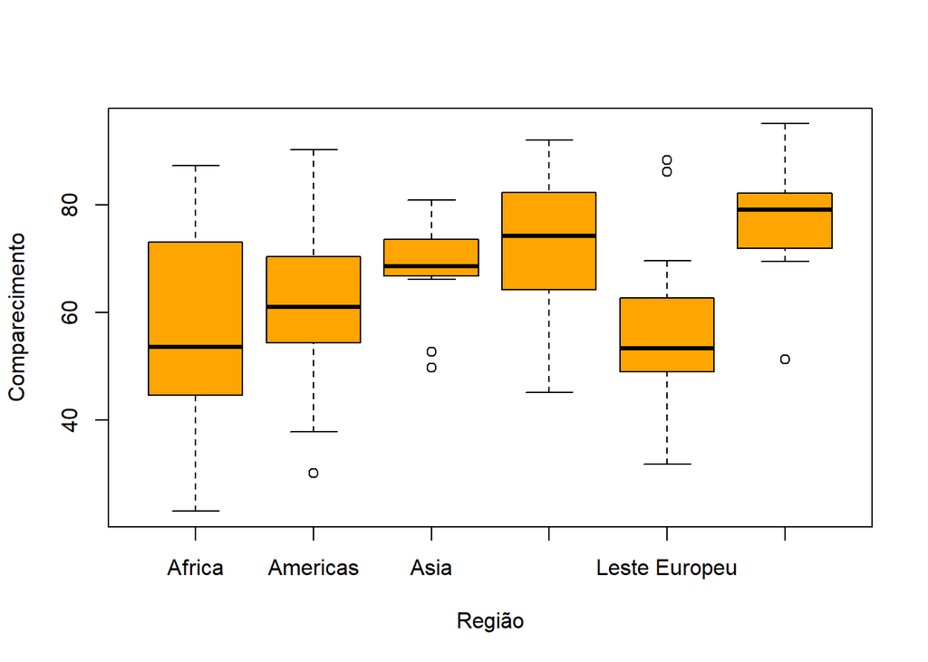

```r
boxplot(base$Tornout ~ base$Region,
        col = "orange", ylab="Comparecimento", xlab="Região")
```

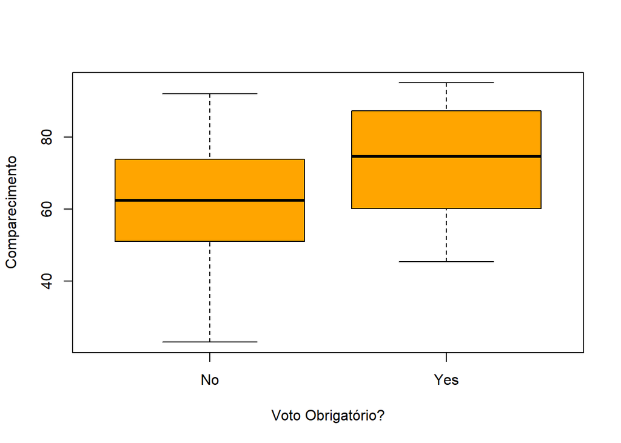

```r
boxplot(base$Tornout ~ base$Compulsory,
        col = "orange", ylab="Comparecimento", xlab="Voto Obrigatório?")
```

Percebe-se que há associações mútuas entre as variáveis.

# Regressão

$Modelo 1$ - Obrigatoriedade explica Comparecimento?

$Modelo 2$ - Região explica comparecimento?

$Modelo Completo:$

$Comparecimento = Intercepto + Obrigatoriedade + Região + e$

```r
modelo_Obrig <- lm(Tornout ~ Compulsory, data = base) # modelo simples 1
modelo_region <- lm(Tornout ~ Region, data = base) # modelo simples 2
modelo_full <- lm(Tornout ~ Compulsory + Region, data = base) # modelo completo
huxreg(modelo_Obrig, modelo_region, modelo_full, stars = c(`*` = 0.1, `**` = 0.05,
                                  `***` = 0.01), statistics = c("N. obs." = "nobs", "R2" = "r.squared",
                                                                "AIC" = "AIC"))
```

|  | (1) | (2) | (3) |
| --- | --- | --- | --- |
| (Intercept) | 62.073 *** | 56.635 *** | 56.231 *** |
|  | (1.577) | (3.037) | (2.957) |
| CompulsoryYes | 10.758 *** |  | 9.276 *** |
|  | (3.571) |  | (3.410) |
| RegionAmericas |  | 6.434 | 3.845 |
|  |  | (4.008) | (4.013) |
| RegionAsia |  | 11.242 ** | 9.958 * |
|  |  | (5.339) | (5.214) |
| RegionEuropa Ocidental |  | 15.633 *** | 14.490 *** |
|  |  | (4.250) | (4.155) |
| RegionLeste Europeu |  | 0.124 | -0.864 |
|  |  | (4.453) | (4.346) |
| RegionOceania |  | 20.924 *** | 18.235 *** |
|  |  | (5.726) | (5.656) |
| N. obs. | 118 | 118 | 118 |
| R2 | 0.073 | 0.196 | 0.246 |
| AIC | 983.656 | 974.846 | 969.233 |
| *** p < 0.01; ** p < 0.05; * p < 0.1. |  |  |  |

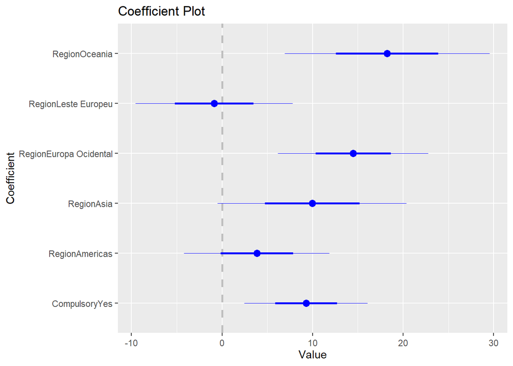

```r
coefplot(modelo_full, intercept = F)
```

Algumas regiões são explicativas (África é referência, todas são comparadas com essa). Para outras comparações verificar os diferentes impactos. Oceania e Europa Ocidental tem os maiores efeitos.

Obrigatoriedade é explicativo.

Abaixo o diagnóstico residual do modelo completo>

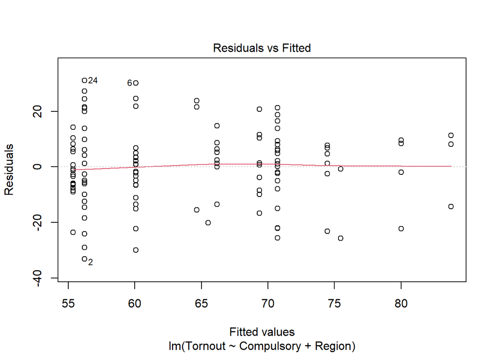

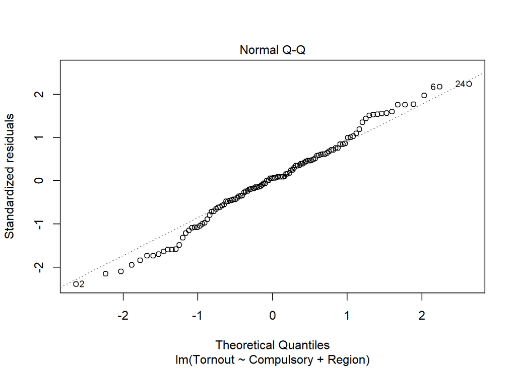

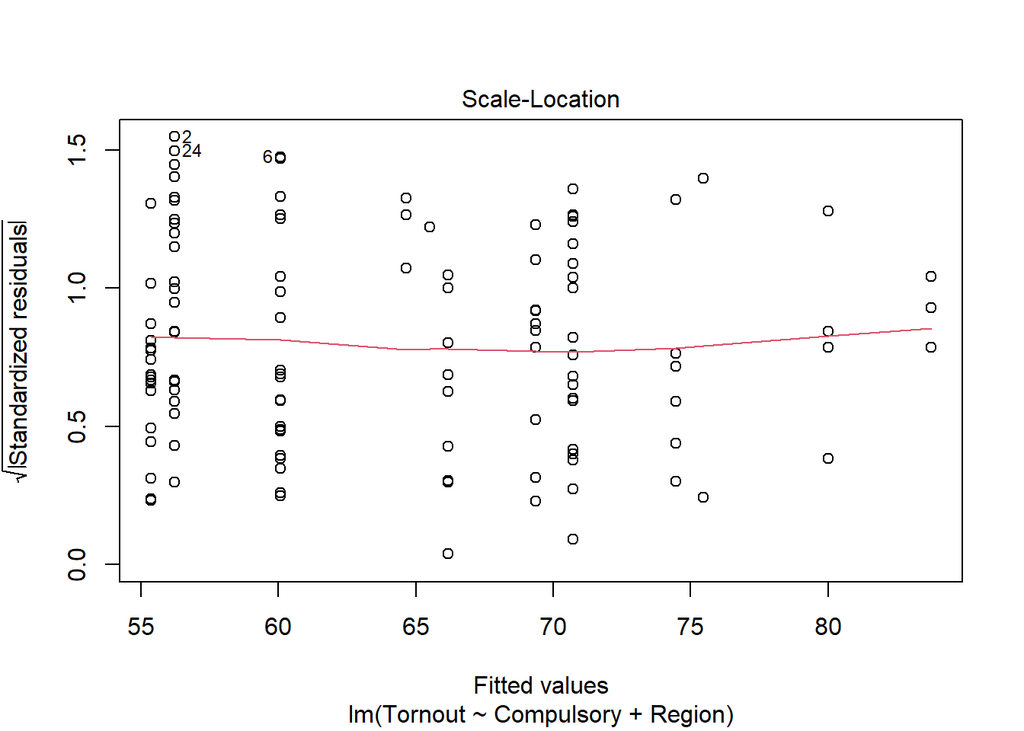

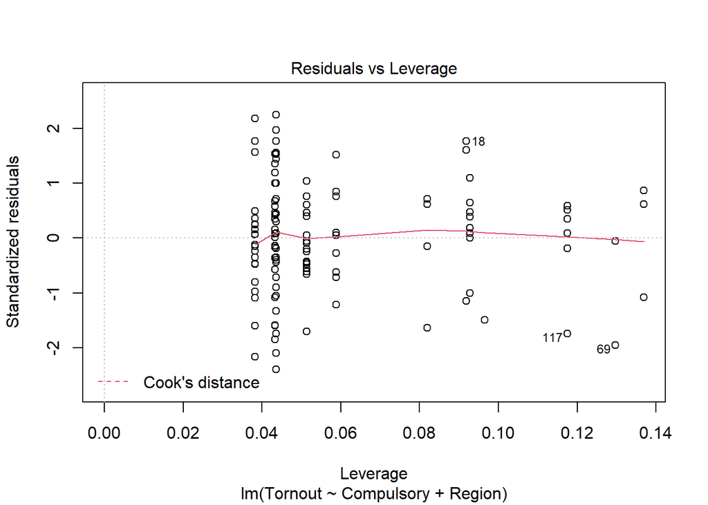

```r
plot(modelo_full) # a segunda
```

```r
ols_vif_tol(modelo_full)
```

| Variables | Tolerance | VIF |
| --- | --- | --- |
| CompulsoryYes | 0.932 | 1.07 |
| RegionAmericas | 0.545 | 1.83 |
| RegionAsia | 0.74 | 1.35 |
| RegionEuropa Ocidental | 0.608 | 1.64 |
| RegionLeste Europeu | 0.64 | 1.56 |
| RegionOceania | 0.754 | 1.33 |

VIF ok (“VIF de 1 indica que não há correlação entre um determinado preditor e os demais incluídos no modelo, logo, não ocorre a inflação do seu coeficiente estimado”)

abaixo análise breve dos resídos

```r
resid <- (cbind(base$Tornout, predict(modelo_full), residuals(modelo_full)))
```

Argélia e Venzeula foram os casos em que ocorreu maior imprevisbilidade negativa (menor participação que o previsto pelo modelo). Não surpreende dado recentes crises de legitimidade nesses países.

Brasil previu 10% a menos de votação (talvez o fato de ser junto com a de presidente, não verificado)

# O peso em cada Região

Regreessões separadas para cada região,

Modelo 1 - África

Modelo 2 - Américas

Modelo 3 e 4 - Ásia e Oceania (sem separação e com separação)

Modelo 5 e 6- Europa (ocidental + Oriental) (sem separação e com separação)

```r
#criando bases e modelos  de cada região
# Africa
Africa <- base%>%
  filter(Region == "Africa")
modelo_Africa <- lm(Tornout ~ Compulsory, data = Africa)
# Americas
Americas <- base%>%
  filter(Region == "Americas")
modelo_Americas <- lm(Tornout ~ Compulsory, data = Americas)
#Asia/Oceania
Asia_Oceania <- base%>%
  filter(Region == "Asia"| Region == "Oceania")
modelo_AsiaOceania1 <- lm(Tornout ~ Compulsory, data = Asia_Oceania)
modelo_AsiaOceania2 <- lm(Tornout ~ Compulsory + Region, data = Asia_Oceania)
#Europa
Europa <- base%>%
  filter(Region == "Leste Europeu"| Region == "Europa Ocidental")
modelo_Europa1 <- lm(Tornout ~ Compulsory, data = Europa)
modelo_Europa2 <- lm(Tornout ~ Compulsory + Region, data = Europa)
```

```r
huxreg(modelo_Africa, modelo_Americas, modelo_AsiaOceania1, modelo_AsiaOceania2, modelo_Europa1, modelo_Europa2, stars = c(`*` = 0.1, `**` = 0.05,
                                  `***` = 0.01), statistics = c("N. obs." = "nobs", "R2" = "r.squared",
                                                                "AIC" = "AIC"))
```

|  | (1) | (2) | (3) | (4) | (5) | (6) |
| --- | --- | --- | --- | --- | --- | --- |
| (Intercept) | 57.145 *** | 59.233 *** | 70.919 *** | 67.254 *** | 63.027 *** | 70.051 *** |
|  | (3.993) | (2.971) | (3.086) | (3.571) | (2.436) | (2.748) |
| CompulsoryYes | -11.745 | 11.892 ** | 5.257 | 3.424 | 13.770 ** | 13.298 ** |
|  | (19.151) | (5.231) | (6.172) | (5.922) | (6.107) | (5.260) |
| RegionOceania |  |  |  | 9.164 * |  |  |
|  |  |  |  | (5.155) |  |  |
| RegionLeste Europeu |  |  |  |  |  | -15.287 *** |
|  |  |  |  |  |  | (3.863) |
| N. obs. | 23 | 31 | 20 | 20 | 44 | 44 |
| R2 | 0.018 | 0.151 | 0.039 | 0.189 | 0.108 | 0.354 |
| AIC | 203.965 | 253.793 | 159.886 | 158.476 | 366.048 | 353.816 |
| *** p < 0.01; ** p < 0.05; * p < 0.1. |  |  |  |  |  |  |